# Queller-Phil-ADA-homework-3

Phil Queller

4/26/2020

# Challenge 1

```r
#read in data

k <-read.csv("~/Desktop/KamilarDATA.csv")
head(k)
```

```
##               Scientific_Name          Family          Genus      Species
## 1 Allenopithecus_nigroviridis Cercopithecidae Allenopithecus nigroviridis
## 2         Allocebus_trichotis Cercopithecidae      Allocebus    trichotis
## 3           Alouatta_belzebul        Atelidae       Alouatta     belzebul
## 4             Alouatta_caraya        Atelidae       Alouatta       caraya
## 5            Alouatta_guariba        Atelidae       Alouatta      guariba
## 6           Alouatta_palliata        Atelidae       Alouatta     palliata
##   Brain_Size_Species_Mean Brain_Size_Female_Mean   Brain_size_Ref
## 1                   58.02                  53.70 Isler et al 2008
## 2                      NA                     NA
## 3                   52.84                  51.19 Isler et al 2008
## 4                   52.63                  47.80 Isler et al 2008
## 5                   51.70                  49.08 Isler et al 2008
## 6                   49.88                  48.04 Isler et al 2008
##   Body_mass_male_mean Body_mass_female_mean Mass_Dimorphism
```

[output cut: 62 more lines]

For this exercise, the end aim is to fit a simple linear regression model to predict longevity (MaxLongevity_m) measured in months from species’ brain size (Brain_Size_Species_Mean) measured in grams. Do the following for both longevity~brain size and log(longevity)~log(brain size). Fit the regression model and, using {ggplot2}, produce a scatterplot with the fitted line superimposed upon the data. Append the the fitted model equation to your plot.

```r
r <- lm(MaxLongevity_m ~ Brain_Size_Species_Mean, data = k, level = 0.90)
tidy(r)
```

```
## # A tibble: 2 x 5
##   term                    estimate std.error statistic  p.value
##   <chr>                      <dbl>     <dbl>     <dbl>    <dbl>
## 1 (Intercept)               249.      11.1        22.4 8.91e-46
## 2 Brain_Size_Species_Mean     1.22     0.110      11.1 2.69e-20
```

Raw values:

```r
alpha <- 0.1
ci <- predict(r,
  newdata = data.frame(Brain_Size_Species_Mean = seq(min(k$Brain_Size_Species_Mean, na.rm = TRUE), max(k$Brain_Size_Species_Mean, na.rm = TRUE), by = 1)),
  interval = "confidence", level = 1 - alpha
)
ci <- data.frame(ci)
ci <- cbind(seq(min(k$Brain_Size_Species_Mean, na.rm = TRUE), max(k$Brain_Size_Species_Mean, na.rm = TRUE), by = 1), ci)


pi <- predict(r,
  newdata = data.frame(Brain_Size_Species_Mean = seq(min(k$Brain_Size_Species_Mean, na.rm = TRUE), max(k$Brain_Size_Species_Mean, na.rm = TRUE), by = 1)),
  interval = "prediction", level = 1 - alpha
)
pi <- data.frame(pi)
head(pi)
```

```
##        fit       lwr      upr
## 1 250.9376  99.19856 402.6766
## 2 252.1556 100.43137 403.8798
## 3 253.3736 101.66396 405.0832
## 4 254.5916 102.89633 406.2868
## 5 255.8096 104.12849 407.4906
## 6 257.0275 105.36043 408.6947
```

```r
i <- cbind(ci, pi)
head(i)
```

```
##   seq(min(k$Brain_Size_Species_Mean, na.rm = TRUE), max(k$Brain_Size_Species_Mean,
## 1                                                                              1.63
## 2                                                                              2.63
## 3                                                                              3.63
## 4                                                                              4.63
## 5                                                                              5.63
## 6                                                                              6.63
##        fit      lwr      upr      fit       lwr      upr
## 1 250.9376 232.7302 269.1450 250.9376  99.19856 402.6766
## 2 252.1556 234.0721 270.2391 252.1556 100.43137 403.8798
## 3 253.3736 235.4130 271.3341 253.3736 101.66396 405.0832
## 4 254.5916 236.7529 272.4302 254.5916 102.89633 406.2868
## 5 255.8096 238.0918 273.5273 255.8096 104.12849 407.4906
## 6 257.0275 239.4296 274.6255 257.0275 105.36043 408.6947
```

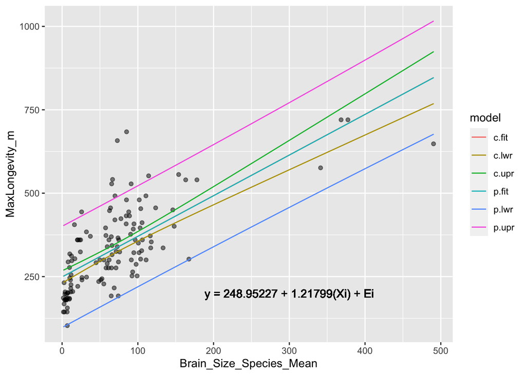

```r
names(i) <- c("weight", "c.fit", "c.lwr", "c.upr", "p.fit", "p.lwr", "p.upr")

long <- pivot_longer(i, c.fit:p.upr, names_to = "model")

g <- ggplot(data = k, aes(x = Brain_Size_Species_Mean, y = MaxLongevity_m)) +
  geom_point(alpha = 0.5) +
  geom_line(data = long, aes(x = weight, y = value, group = model, color = model)) +
  geom_text(x = 300, y = 200, label = "y = 248.95227 + 1.21799(Xi) + Ei")


g
```

Some summary stats from the model:

```r
t <- tidy(r)
print(t)
```

```
## # A tibble: 2 x 5
##   term                    estimate std.error statistic  p.value
##   <chr>                      <dbl>     <dbl>     <dbl>    <dbl>
## 1 (Intercept)               249.      11.1        22.4 8.91e-46
## 2 Brain_Size_Species_Mean     1.22     0.110      11.1 2.69e-20
```

```r
c <- confint(r, level = 0.90)
print(c)
```

```
##                                5 %      95 %
## (Intercept)             230.540738 267.36379
## Brain_Size_Species_Mean   1.035571   1.40041
```

beta1 = 1.21799

beta0 = 248.95227

beta1 does not equal zero so the null hypothesis is rejected, which indicates that species’ longevity increases as a function of brain size.

90% confidence intervals for the slope are 1.035571 and 1.40041

Produce a point estimate and associated 90% prediction interval for the longevity of a species whose brain weight is 750 gm.

```r
m.summary <- tidy(r)
beta0 <- m.summary %>%
  filter(term == "(Intercept)") %>%
  pull(estimate)
beta1 <- m.summary %>%
  filter(term == "Brain_Size_Species_Mean") %>%
  pull(estimate)
(h.hat <- beta1 * 750 + beta0)
```

```
## [1] 1162.445
```

Do you trust the model to predict observations accurately for this value of the explanatory variable? Why or why not?

I do not trust this prediction very much because the the value of the explanatory value falls among those values of x that have the least trustworthy confidence intervals (the upper right portion of the graph). This is because the 4 points in this region are so different than the others, its hard to tell if they are pulling the line artificially.

log values:

```r
log(HomeRange_km2) ~ log(Body_mass_female_mean)
```

```
## log(HomeRange_km2) ~ log(Body_mass_female_mean)
```

```r
#make new columns in the dataframe for log transformed values:

log_df <- k %>% mutate(
  log_MaxLongevity_m = log(MaxLongevity_m),
  log_Brain_Size_Species_Mean = log(Brain_Size_Species_Mean),
  log_HomeRange_km2 = log(HomeRange_km2),
  log_Body_mass_female_mean = log(Body_mass_female_mean)
)

head(log_df)
```

```
##               Scientific_Name          Family          Genus      Species
## 1 Allenopithecus_nigroviridis Cercopithecidae Allenopithecus nigroviridis
## 2         Allocebus_trichotis Cercopithecidae      Allocebus    trichotis
## 3           Alouatta_belzebul        Atelidae       Alouatta     belzebul
## 4             Alouatta_caraya        Atelidae       Alouatta       caraya
## 5            Alouatta_guariba        Atelidae       Alouatta      guariba
## 6           Alouatta_palliata        Atelidae       Alouatta     palliata
##   Brain_Size_Species_Mean Brain_Size_Female_Mean   Brain_size_Ref
## 1                   58.02                  53.70 Isler et al 2008
## 2                      NA                     NA
## 3                   52.84                  51.19 Isler et al 2008
## 4                   52.63                  47.80 Isler et al 2008
## 5                   51.70                  49.08 Isler et al 2008
## 6                   49.88                  48.04 Isler et al 2008
##   Body_mass_male_mean Body_mass_female_mean Mass_Dimorphism
```

[output cut: 69 more lines]

```r
log_fit <- lm(log_MaxLongevity_m ~ log_Brain_Size_Species_Mean, data = log_df, level = 0.90)
tidy(log_fit)
```

```
## # A tibble: 2 x 5
##   term                        estimate std.error statistic   p.value
##   <chr>                          <dbl>     <dbl>     <dbl>     <dbl>
## 1 (Intercept)                    4.88     0.0691      70.6 3.32e-103
## 2 log_Brain_Size_Species_Mean    0.234    0.0178      13.1 2.17e- 25
```

```r
alpha <- 0.1
ci <- predict(log_fit,
  newdata = data.frame(log_Brain_Size_Species_Mean = seq(min(log_df$log_Brain_Size_Species_Mean, na.rm = TRUE), max(log_df$log_Brain_Size_Species_Mean, na.rm = TRUE), by = 1)),
  interval = "confidence", level = 1 - alpha
)
ci <- data.frame(ci)
ci <- cbind(seq(min(log_df$log_Brain_Size_Species_Mean, na.rm = TRUE), max(log_df$log_Brain_Size_Species_Mean, na.rm = TRUE), by = 1), ci)


pi <- predict(log_fit,
  newdata = data.frame(log_Brain_Size_Species_Mean = seq(min(log_df$log_Brain_Size_Species_Mean, na.rm = TRUE), max(log_df$log_Brain_Size_Species_Mean, na.rm = TRUE), by = 1)),
  interval = "prediction", level = 1 - alpha
)
pi <- data.frame(pi)
head(pi)
```

```
##        fit      lwr      upr
## 1 4.993352 4.569469 5.417234
## 2 5.227501 4.809179 5.645823
## 3 5.461651 5.046859 5.876443
## 4 5.695800 5.282457 6.109144
## 5 5.929950 5.515952 6.343948
## 6 6.164100 5.747352 6.580847
```

```r
i <- cbind(ci, pi)
head(i)
```

```
##   seq(min(log_df$log_Brain_Size_Species_Mean, na.rm = TRUE), max(log_df$log_Brain_Size_Species_Mean,
## 1                                                                                             0.48858
## 2                                                                                             1.48858
## 3                                                                                             2.48858
## 4                                                                                             3.48858
## 5                                                                                             4.48858
## 6                                                                                             5.48858
##        fit      lwr      upr      fit      lwr      upr
## 1 4.993352 4.892460 5.094244 4.993352 4.569469 5.417234
## 2 5.227501 5.153365 5.301638 5.227501 4.809179 5.645823
## 3 5.461651 5.411105 5.512197 5.461651 5.046859 5.876443
## 4 5.695800 5.658987 5.732614 5.695800 5.282457 6.109144
## 5 5.929950 5.886392 5.973508 5.929950 5.515952 6.343948
## 6 6.164100 6.099439 6.228760 6.164100 5.747352 6.580847
```

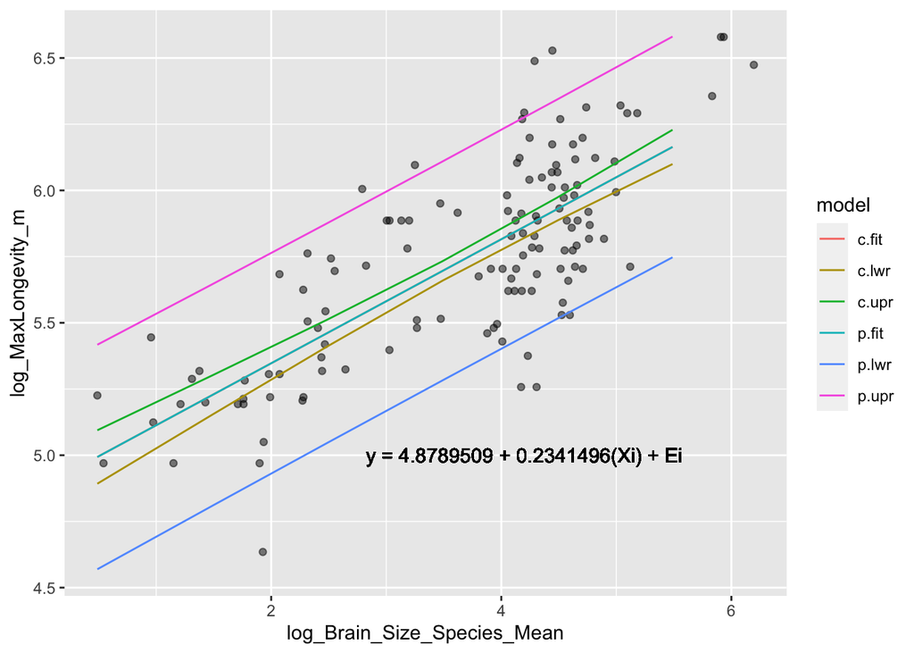

```r
names(i) <- c("weight", "c.fit", "c.lwr", "c.upr", "p.fit", "p.lwr", "p.upr")

long <- pivot_longer(i, c.fit:p.upr, names_to = "model")

g <- ggplot(data = log_fit, aes(x = log_Brain_Size_Species_Mean, y = log_MaxLongevity_m)) +
  geom_point(alpha = 0.5) +
  geom_line(data = long, aes(x = weight, y = value, group = model, color = model)) +
  geom_text(x = 4.2, y = 5, label = "y = 4.8789509 + 0.2341496(Xi) + Ei")

g
```

Some summary stats from the model:

```r
t <- tidy(log_fit)
print(t)
```

```
## # A tibble: 2 x 5
##   term                        estimate std.error statistic   p.value
##   <chr>                          <dbl>     <dbl>     <dbl>     <dbl>
## 1 (Intercept)                    4.88     0.0691      70.6 3.32e-103
## 2 log_Brain_Size_Species_Mean    0.234    0.0178      13.1 2.17e- 25
```

```r
c <- confint(log_fit, level = 0.90)
print(c)
```

```
##                                   5 %      95 %
## (Intercept)                 4.7644934 4.9934084
## log_Brain_Size_Species_Mean 0.2046396 0.2636595
```

beta1 = 0.2341496

beta0 = 4.8789509

beta1 does not equal zero so the null hypothesis is rejected, which indicates that species’ longevity increases as a function of brain size.

90% confidence intervals for the slope are 0.2046396 and 0.2636595

Produce a point estimate and associated 90% prediction interval for the longevity of a species whose brain weight is 750 gm.

```r
m.summary <- tidy(log_fit)
beta0 <- m.summary %>%
  filter(term == "(Intercept)") %>%
  pull(estimate)
beta1 <- m.summary %>%
  filter(term == "log_Brain_Size_Species_Mean") %>%
  pull(estimate)
(h.hat <- beta1 * log(750) + beta0)
```

```
## [1] 6.429038
```

Do you trust the model to predict observations accurately for this value of the explanatory variable? Why or why not?

I trust this prediction because the model has narrow confidence intervals.

Looking at your two models (i.e., untransformed versus log-log transformed), which do you think is better? Why?

I think the log transformed model is more useful. The more narrow confidence intervals gives it more accurate predictions.

# Challenge 2

Using the “KamilarAndCooperData.csv” dataset, run a linear regression looking at log(HomeRange_km2) in relation to log(Body_mass_female_mean) and report your β coeffiecients (slope and intercept).

```r
fit <- lm(log_HomeRange_km2 ~ log_Body_mass_female_mean, data = log_df)
results <- tidy(fit, conf.int = TRUE, conf.level = .95) %>%
  select(term, estimate, std.error, conf.low, conf.high)
head(results)
```

```
## # A tibble: 2 x 5
##   term                      estimate std.error conf.low conf.high
##   <chr>                        <dbl>     <dbl>    <dbl>     <dbl>
## 1 (Intercept)                  -9.44    0.673   -10.8       -8.11
## 2 log_Body_mass_female_mean     1.04    0.0849    0.869      1.20
```

B0 = -9.44123 B1 = 1.03643

Then, use bootstrapping to sample from the dataset 1000 times with replacement, each time fitting the same model and calculating the appropriate coefficients. [The size of each sample should be equivalent to the total number of observations in the dataset.] This generates a bootstrap sampling distribution for each β coefficient. Plot a histogram of these sampling distributions for β0 and β1.

```r
boot <- tibble()

for (i in 1:1000) {
  s <- sample_n(log_df, size = nrow(log_df), replace = TRUE)
  fit <- lm(s, formula = log_HomeRange_km2 ~ log_Body_mass_female_mean)
  tidy <- tidy(fit) %>% pull(estimate) -> results
 names(results) <- tidy(fit)$term
 boot <- bind_rows(boot, results)
}


names(boot) <- c("beta0", "beta1")
boot
```

```
## # A tibble: 1,000 x 2
##     beta0 beta1
##     <dbl> <dbl>
##  1 -10.0  1.12
##  2  -9.31 1.03
##  3  -8.76 0.914
##  4 -10.1  1.10
##  5 -11.4  1.28
##  6  -9.31 1.01
##  7  -9.63 1.04
##  8  -9.55 1.06
##  9  -9.22 1.02
## 10  -8.98 0.958
## # … with 990 more rows
```

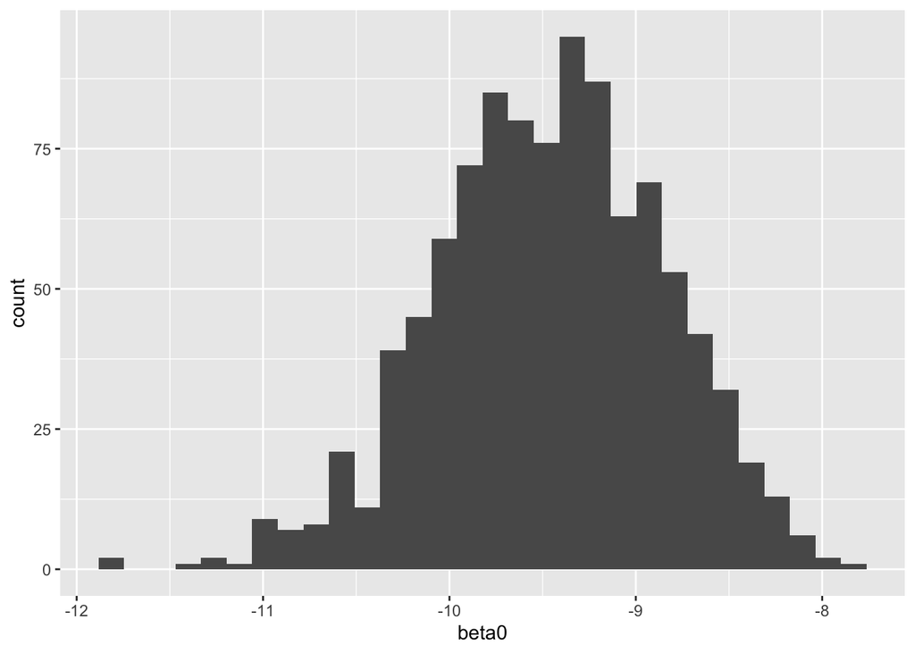

```r
B0_hist <- ggplot(boot, aes(x = beta0)) +
                  geom_histogram()

B0_hist
```

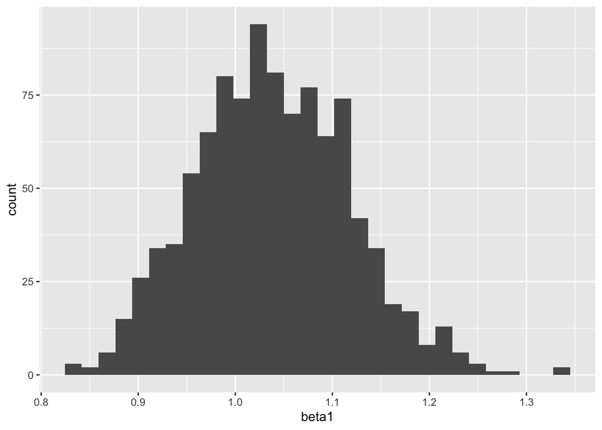

```r
B1_hist <- ggplot(boot, aes(x = beta1)) +
                  geom_histogram()

B1_hist
```

Estimate the standard error for each of your β coefficients as the standard deviation of the sampling distribution from your bootstrap.

```r
se_beta0 <- sd(boot$beta0)
se_beta0
```

```
## [1] 0.613045
```

```r
se_beta1 <- sd(boot$beta1)
se_beta1
```

```
## [1] 0.07930673
```

Also determine the 95% CI for each of your β coefficients based on the appropriate quantiles from your sampling distribution.

```r
beta1_upr_ci <- quantile(boot$beta1, 0.975)
beta1_upr_ci
```

```
##    97.5%
## 1.206768
```

```r
beta1_lwr_ci <- quantile(boot$beta1, 0.025)
beta1_lwr_ci
```

```
##      2.5%
## 0.8936516
```

```r
beta0_upr_ci <- quantile(boot$beta0, 0.975)
beta0_upr_ci
```

```
##     97.5%
## -8.352893
```

```r
beta0_lwr_ci <- quantile(boot$beta0, 0.025)
beta0_lwr_ci
```

```
##      2.5%
## -10.73189
```

How do the SEs estimated from the bootstrap sampling distribution compare to those estimated mathematically as part of lm() function?

lm() function

se_beta0 = 0.67293459 se_beta1 = 0.08487709

They standard erros calculated from the lm() function are very similar to those derived from bootstrapping.

How do you bootstrap CIs compare to those estimated mathematically as part of the lm() function?

lm(): beta1_upr_ci = 1.204292 beta1_lwr_ci = 0.8685707

lm() beta0_upr_ci = -8.110374 beta0_lwr_ci = -10.7720889

The confidence intervals calculated from the lm() function are similar to those derived from bootstrapping.